# Mental Health & Music

### Authors

Alice Chen, Aaliyah Viloria, Siyi Xu, Michelle Zhang

### Date

Winter 2023

### Abstract

Our main question is how do music-listening habits relate to the listener’s mental health? This question is important because music is a powerful tool that can affect people’s lives on varying levels. To address the question, we will analyze a dataset containing information on respondent’s age, number of hours respondents listen to music per day, self-reported mental health disorders, and the overall effect of music on respondent’s mental health.

### Keywords

Mental Health, Music, Music Therapy

### Introduction

- How often do respondents listen to music per day?
- Do respondents generally listen to music while performing other tasks (studying, working, etc)? If so, does it allow them to work on tasks more efficiently?
- Does music improve or worsen a respondent’s mental health conditions overall?
- Is there a correlation between listening hours, and the respondents’ age and preferred genre?

These questions are important for our research as it allows us to find correlations between music and mental health, and answer other related questions such as “does an increase in the number of hours the respondent listens to music per day correspond to a better mental health state?”, and if certain habits like multitasking can be of benefit for one’s mental health.

### Related Work

Music is a crucial element of everyday life for most people. It plays a big role in people’s cultures and backgrounds and is often played or listened for all ages. It can be a crucial part of developmental stages in early life and create healthy bonds with one another. Music is a versatile instrument that can be used not only for entertainment but for mental health purposes as well.

1. In the study titled, [Comparing Educational Music Therapy Interventions via Stages of Recovery with Adults in an Acute Care Mental Health Setting](https://doi.org/10.1007/s10597-019-00380-1), researchers performed studies that compared 69 adult patients in an acute mental health unit. They made three groups, the controlled, educational lyrical analysis group (ELA), and the educational songwriting (ESW) which contributed to the question of wheater music helped these patients in these units during their time of recovery. Although there wasn’t a significant difference between the groups, it still showed a better overall score of recovery compared to the control group.
2. On the other hand, a review article called, [Music, mental health, and immunity](https://www.ncbi.nlm.nih.gov/pmc/articles/PMC8566759/) talks about the importance of music therapy. It involves a therapeutic process developed between the patient and their therapist through the use of personalized music experiences. Utilizing music to treat mental illnesses such as anxiety, depression, and schizophrenia has improved symptoms, This is because music therapy allows patients to express emotions while at a stage of relaxation and feelings of safety. In addition, there have been studies showing that listening to pleasurable music increases the release of dopamine and network connectivity.
3. Finally, an article published by AAPR called [Music Can Be a Great Mood Booster](https://www.aarp.org/health/brain-health/info-2020/music-mental-health.html) ask the questions of how music can impact your life. It describes music therapy as an established healthcare profession. In a study of 3,185 participants, they found that using music came to approach goals of decreasing pain, finding motivation, and helping with depression. Also, decrease the levels of cortisol during times of stress or prolonged stress.

References

Adler, S. E. (2022, August 10). Positive effects of music for Mental Health. AARP. Retrieved February 1, 2023, from https://www.aarp.org/health/brain-health/info-2020/music-mental-health.html

Rebecchini L. Music, mental health, and immunity. Brain Behav Immun Health. 2021 Oct 21;18:100374. doi: 10.1016/j.bbih.2021.100374. PMID: 34761245; PMCID: PMC8566759.

Silverman, M.J. Comparing Educational Music Therapy Interventions via Stages of Recovery with Adults in an Acute Care Mental Health Setting: A Cluster-Randomized Pilot Effectiveness Study. Community Ment Health J 55, 624–630 (2019). https://doi.org/10.1007/s10597-019-00380-1

### The Dataset

Where did you find the data? Please include a link to the data source

- We found the data on Kaggle: [an external link to the data source](https://www.kaggle.com/datasets/catherinerasgaitis/mxmh-survey-results?resource=download).

Who collected the data?

- It was collected by Catherine Rasgaitis, an undergraduate from the University of Washington.

How was the data collected or generated?

- The data was collected via a Google form which was posted on several social media platforms such as Reddit or Discord.
- Rasgaitis also propagandized the form in public locations such as libraries as posters or business cards. In this form with only brief questions, respondents ranked how frequently they listened to each of 16 musical genres, and ranked Anxiety, Depression, Insomnia, and OCD on a scale of 0 to 10.

Why was the data collected?

- The data was collected because Rasgaitis aimed to find out any correlations between a person’s musical preferences and their self-reported mental health, which wished to provide insights into how music therapy could be used as a treatment of mental health problems.

How many features (columns) are in the data?

- There are 33 features in the data.

What, if any, ethical questions or questions of power do you need to consider when working with this data?

- One ethical question that we need to consider is to respect respondents’ privacy. The last column (feature) of the data records whether the respondent permits to publicize the data which contains his/her personal information.

What are possible limitations or problems with this data? (at least 200 words)

- A possible limitation with this data is that it is mainly collected through certain online platforms. Although the respondents are not limited by age or location, the process of data collection itself might exclude those who do not use these online platforms, which leads to a limited sample size.
- Another limitation is that the data does not include additional questions about demographics (country, sex, etc.) which could add more interesting insights. Similarly, there are other unrepresented music genres which may also help identify the relationship between music taste and mental health.

### Implications

Exploring the correlations between an individual’s music taste and their mental health can help us to get an ideal understanding on how music therapy improves an individual’s stress, mood, and overall mental health. The finding that music therapy is an effective way to improve an individual’s mood can help people who are suffering from the mental health issues to know the way to promote mental health by using music therapy. Assuming answers to the research questions, the time respondents spend on music services can help us to know the best time duration for improving mood. For example, finding out the best time duration can prevent people from listening too long to cause the tiring mood and noisy feeling. The dataset can also help us to know how music impacts our ability when performing the tasks, finding out the most suitable music genre for healing and working. The possible implication for technologists could be implementing the function in a music platform to be able to organize the types of music and utilities of music by personal preference. For example, the music platform can have a category about music therapy with music that the therapist recommended and the music people personally like. Therefore, studying the relationship between an individual’s music taste and mental health allows people to know that different music genres have different impacts on people’s mood, so people can use music therapy to listen to specific music genres to heal their emotion.

### Summary Information

This dataset about mental health and music includes 736 responses, and 33 features. We have compared listening habits and effects between each number of listening hours in the aggregate table and the three charts below). There are 27 groups of listening hours. Out of all the respondents, 78.67% listen to music while working/studying, Rock is the most common genre listened to, 73.64% reported improved health, 2.31% reported worsened health, 22.96% reported no effect of music on their mental health, and the remaining 1.09% did not respond to the question.

### Table: Aggregate Music-Listening Data by Number of Listening Hours per Day

| Hours per Day | Number of Reponses | Majority Age | Percentage of Improved Health | Percentage of Worsened Health | Percentage of No Health Effect | Majority Genre | Percentage of Listening While Working/Studying |
| --- | --- | --- | --- | --- | --- | --- | --- |
| 0.00 | 6 | 42 | 33.33 | 16.67 | 50.00 | Rock | 0.00 |
| 0.10 | 1 | 21 | 0.00 | 0.00 | 100.00 | Folk | 100.00 |
| 0.25 | 3 | 37 | 66.67 | 0.00 | 33.33 | Classical | 33.33 |
| 0.50 | 20 | 21 | 70.00 | 5.00 | 25.00 | Rock | 30.00 |
| 0.70 | 1 | 20 | 100.00 | 0.00 | 0.00 | Rock | 0.00 |
| 1.00 | 117 | 21 | 67.52 | 3.42 | 27.35 | Rock | 53.85 |
| 1.50 | 17 | 18 | 58.82 | 5.88 | 23.53 | Rock | 70.59 |
| 2.00 | 173 | 18 | 72.83 | 2.31 | 23.70 | Rock | 78.61 |
| 2.50 | 6 | 16 | 100.00 | 0.00 | 0.00 | Rock | 83.33 |
| 3.00 | 120 | 19 | 71.67 | 1.67 | 25.00 | Rock | 84.17 |
| 4.00 | 83 | 18 | 84.34 | 1.20 | 14.46 | Rock | 86.75 |
| 4.50 | 1 | 23 | 0.00 | 0.00 | 100.00 | Rock | 100.00 |
| 5.00 | 54 | 19 | 81.48 | 1.85 | 16.67 | Rock | 96.30 |
| 6.00 | 47 | 19 | 72.34 | 2.13 | 25.53 | Rock | 100.00 |
| 7.00 | 15 | 14 | 93.33 | 0.00 | 6.67 | Pop | 100.00 |
| 8.00 | 29 | 19 | 75.86 | 0.00 | 24.14 | Rock | 96.55 |
| 9.00 | 3 | 31 | 100.00 | 0.00 | 0.00 | Metal | 100.00 |
| 10.00 | 20 | 27 | 80.00 | 0.00 | 20.00 | Metal | 90.00 |
| 11.00 | 1 | 21 | 100.00 | 0.00 | 0.00 | Metal | 100.00 |
| 12.00 | 9 | 16 | 66.67 | 11.11 | 22.22 | Rock | 88.89 |
| 13.00 | 1 | 30 | 100.00 | 0.00 | 0.00 | K pop | 0.00 |
| 14.00 | 1 | 26 | 0.00 | 0.00 | 100.00 | Hip hop | 100.00 |
| 15.00 | 2 | 16 | 50.00 | 0.00 | 50.00 | EDM | 100.00 |
| 16.00 | 1 | 18 | 100.00 | 0.00 | 0.00 | Jazz | 100.00 |
| 18.00 | 1 | 18 | 100.00 | 0.00 | 0.00 | EDM | 100.00 |
| 20.00 | 1 | 27 | 0.00 | 0.00 | 100.00 | Rock | 100.00 |
| 24.00 | 3 | 17 | 66.67 | 0.00 | 33.33 | Rap | 100.00 |

This table shows aggregate information on listening behavior and the effects of such behavior on mental health, for varying listening hours per day. It is in ascending numerical order of the listening hours, and includes information about the number of responses, the most common age of the respondents, percentage of improved health, worsened health, and non-effected health, most common genre listened to, and percentage of respondents who listen to music while working/studying, all of which, were calculated for each group of listening hours. Looking at a table with 736 rows can be very complicated, especially when you’re comparing values that are grouped by a certain attribute (e.g. compare data values between respondents of the age 18 vs. age 42), because the attribute may be spread out throughout a column. We created this aggregate table to make it easier to do such comparing, and we specifically grouped the data by the number of listening hours, because we wanted to see how the data varies with an increase in listening hours, especially how it has affected respondents’ mental health. For all but 5 of the listening hour groups, at least 50% of the respondents reported improved health (with “no effect” being the majority response for the 5 groups). The first third of the groups (0 ot 2.5 listening hours) had an average of 63.21% improved health, the second third (3 to 10 hours) had an average of 73.22%, and the last third (11 to 24 hours) had an average of 64.82%. While it is difficult to compare these three percentage values between each other, because the number of responses for each group vary greatly (e.g. 1 response could result in 100% improved health), the averages being greater than 50% can show that music brings improvement to mental health overall.

### Chart 1: Hours vs Percentage

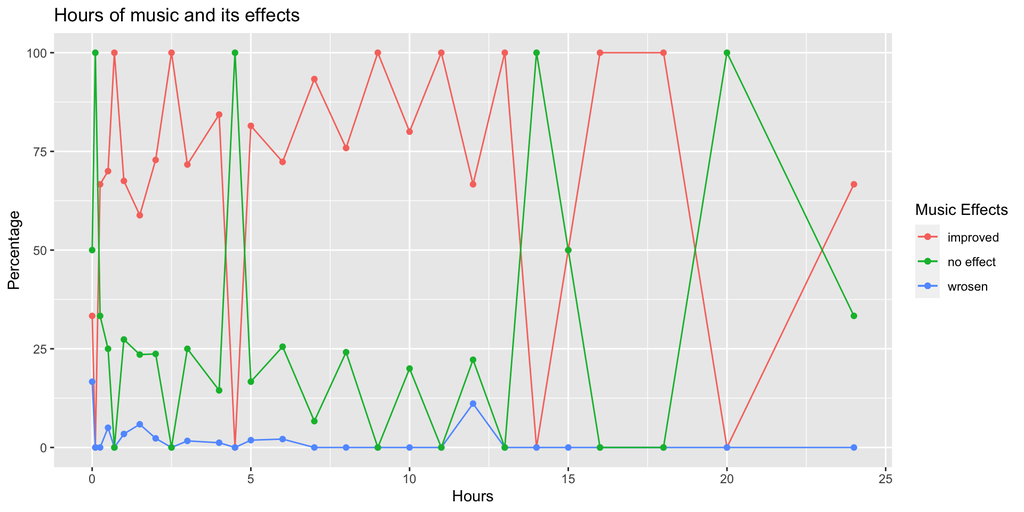

A line graph because it shows the changes over time as a series of data points connected by a line in order to determine the relationship between two sets of values. Which in this case are the hours and the percentage. It shows the Music effects of being “Improved”, “No effect”, and “Worsened” over the period of time people listen to music in color coded lines.

The graph shows the difference that music made a difference in how people felt and improvement on their mood and well-being as much of the results is highly favorable to music and its improvements. And less people felt that music actually worsen their well-being and mood. By looking at this graph, we see that listening to music have some positive effects on people’s mental health and overall well-being.

### Chart 2: While listening & Music effects

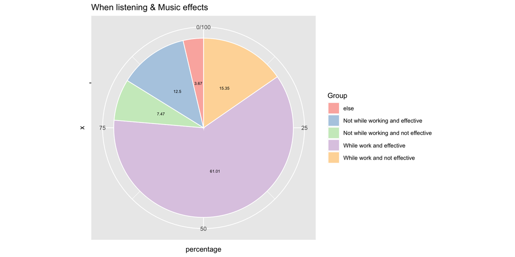

The reason I use pie chart is that it is very clear to see the percentage of effects on how music can impact people when they are doing their tasks or not. It is obvious to see the different groups and their percentage slices to illustrate numerical proportion. There are 5 groups in this dataset. The group of “while work and effective” refers to the group of people who are listening to music while working and also have positive effects. The group of “while work and not effective” refers to the group of people who are listening to music while working and do not have effects. Also, the group of “not while working and effective” means the group of people who not listen to music while working and have positive effects. The group of “not while working and not effective” refers to the group of people who not listen to music while working and have no effects. The fifth group “else” is the group of people with missing information and have worsen effects. As shown in this pie chart, it reveals that there are 61.01 percent of people who listen to music while working and have positive effects, 15.35 percent of people listen to music while working and do not have any effects, 12.5 percent of people not listen to music while working and have positive effects, 7.47 percent of people do not listen to music while working and have no effects, and lastly 3.67% of people with lack of information. Therefore, it obviously demonstrates that people in this dataset largely show music has positive effect on mental health and work emotion when listening to music while working.

### Chart 3: Music Genre vs Music Effects

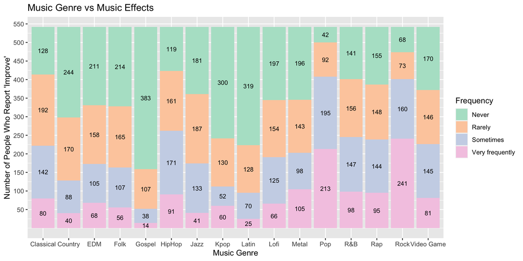

The stacked bar chart represents the number of respondents who report “Improve” in terms of music effects within each music genre (16 music genres in total). Each bar is divided into 4 sub-bars stacked end to end, each sub-bar corresponding to levels of frequency of listening to each music genre, marked by “never, rarely, sometimes, very frequently”.

The reason why I choose this stacked bar chart is that it can clearly show how each music genre has a impact on people’s mental health based on how often they listen to certain type of music. The length of each sub-bar demonstrates which music genre influences people’s mental health the most. By evaluating this chart, we can see that listening to rock music very frequently can have the most postive impact on people’s mental health.